# Project 2 Hospitals and MI’s

November 30, 2016

## Data

Condition-specific mortality measures/readmission measures used in Hospital Inpatient Quality Reporting prgram and publically reported on **Hospital Compare**.

## How was it collected and by whom?

Data was collected from Medicare billing codes provided by Healthcare providers. The agency responsible for harvesting this data is the Centers of Medicare & Medicaid Services' (CMS's)– a branch of the Department of Health and Human Services. Data between July 1, 2012 and June 30, 2015.

## Who is this intended for?

While the CMS's claims there reports are intended for a wide range of readers, there is a fair amount of Jargon.

## Overall Score

\(\uparrow\) Overall.Score - Summarizes more than 60 measures reported on Hospital Compare into a single rating. Seven groups:

- Mortality
- Safety of care
- Readmission
- Patient experience
- Effectiveness of care
- Timeliness of care
- Efficient use of medical imaging

## Quantifying "Worst"

## Risk Standardized Mortality Rate (henceforth known as Death Score)

The effort to maintain public records on a given hospitals Death Scores began in 2007– CMS reported 30-day Death scores for AMI's and HF's for the nations non-federal short-term acute hospitals and critical access hospitals. In an effort to improve these measures in response to stakeholder input/changes in science/changes in coding, measures are revaluated annually by Yale-New Haven Health Services. In order to account for differences in patient mix among hospitals, the death score adjusts for variables that are clinically relevant to the mortality outcome. Complications that arise after initial admission are not factored into this adjusted.

## Who is actually included?

An **Index Admission** is the hospitiliztion to which the mortality outcome is attributed and includes patients that meet the following criteria:

- Aged 65 or over
- Enrolled in Original Medicare for 12 months prior to admission
- Consistent or known vital status with clear demographic (age and gender data)
- **Not** discharged against medical advice
- **Not** transferred from another acute care facility
- **Not** enrolled in Medicare hospice program any time in the 12 months prior to admission
- **Many more special cases** ask us about it after…

## Why the 30-day timeframe?

The measures assess mortality within a 30-day period from the date of the index admission. This is so because, older adult patients are more vulnerable to adverse health outcomes during this timeframe. Thirty days is what has been defined as the clincally meaningful period for hospitals to colloborate with their communities in order to reduce mortality.

## What is the Death Score?

Their approach utilizes a hierachial logistic regression model in which patients are nested within hospitals. This nesting allows the statistician to simulataneously model data at the patient and hospital levels and account for variance in patient outcomes within and between hospitals.

**Patient Level**

**Hospital Level**

**Death Score** Ratio of "Predicted"/"Expected" x National Mortality Rate

**Expected** "Expected" mortality for each hospital is estimated for a given group of patients and using the average hospital-specific effect (average across all hospital specific effects in the sample).

**Predicted** "Predicted" mortality for each hospital is estimated by taking the same group of patients and using that hospital-specific effect.

## Variables

Location - US Counties.

\(\downarrow\) Compl.Score - Measures were complications like 'Blood stream infection after surgery' and 'Serious blood clots after surgery'.

\(\uparrow\) Quests.Score - A questionnaire scored a hospital on a star system of 1-5. Some questions were 'room was "always clean"', and 'Doctors "always" communicated well'.

\(\downarrow\) Infects.score - Includes blood stream infections, UTI's, infections after surgery, and MRSA and C.Diff (Clostridium difficile) infections.

\(\uparrow\) Spends.Score - Medicare Hospital Spending per patient. (Larger better?)

## Variables

\(\downarrow\) Images.score - Such imaging as Cat scans of abdomens, MRI's of spines, and mammography follow-up rates. Up or down?

\(\downarrow\) Values.Payment - Assess Medicare Part A and Part B payments for services. Are price-standardized and risk-adjusted. Purpose is to see whether payments for treatments at a particular hospital is less than or no different than the national average. Retained only payments for acute MI's.

\(\downarrow\) Deaths.Score - Retained measure Acute MI 30 day mortality rate.

\(\downarrow\) Timely.Score - Typically the number of minutes waited for treating MI's by use of fibrinolytic therapy, transfer to another facility for better treatent, Aspirin on arrival, or time to ECG.

## Relationship of overall score to groups, comparing top and bottom 20 counties

## Rank to Overall Score

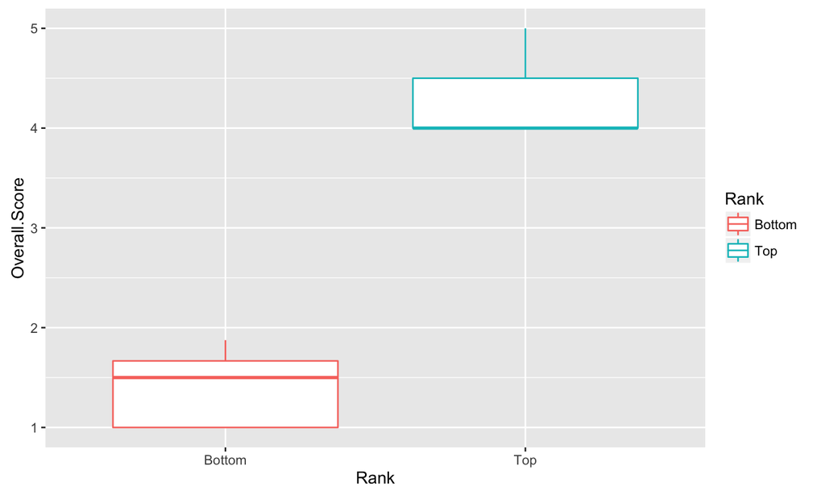

## Rank to Questionnaire Stars

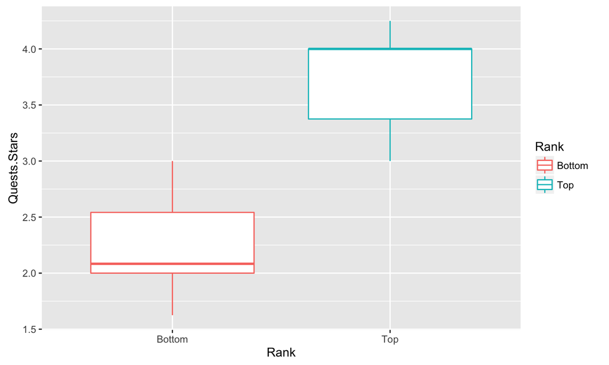

## Rank to Complications

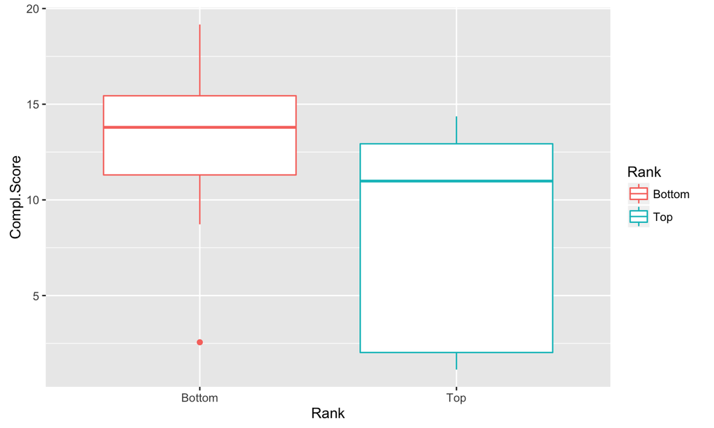

## Rank to Infections Score

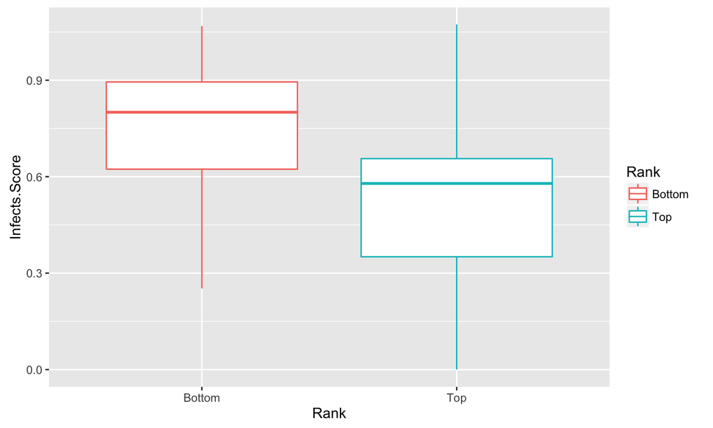

## Rank to Spending Score

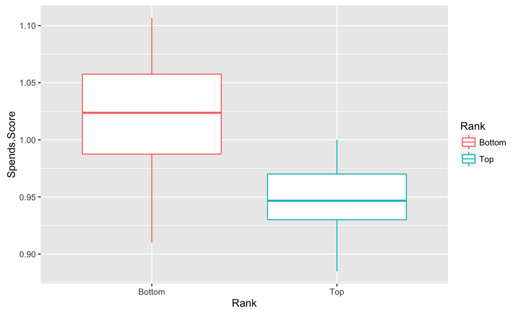

## Rank to Payment Score

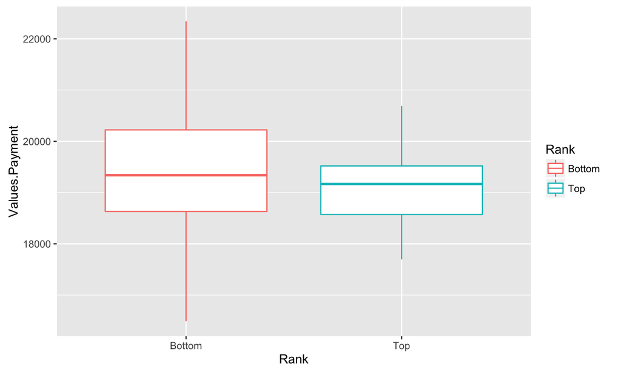

## Rank to Deaths Score

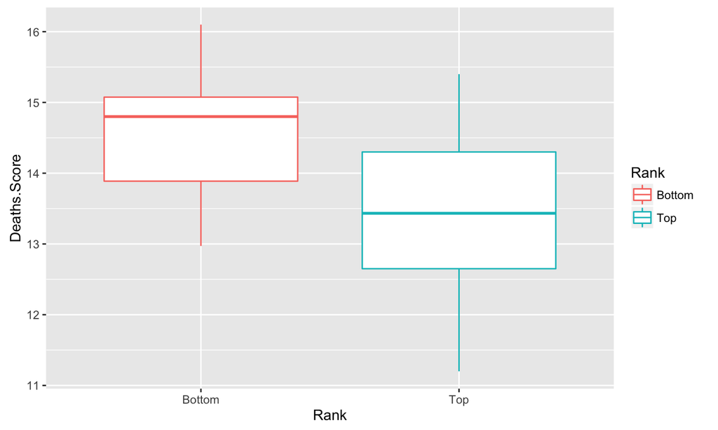

## Rank to Timely Score

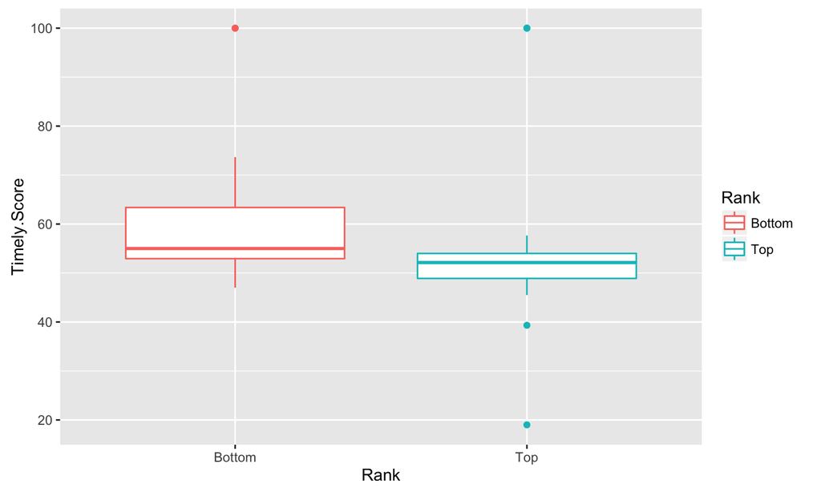

## Boxplot summary

See general trend of overall top ranked counties have lower scores (lower is better) compared to worst ranked counties.

## State level

Aggregated on States to find States with the best overall score and the lowest Death score.